# Business Problem Statement:

A group of customers were given an offer in person that they can get a loan at discounted rate and processing fee will be waived off. A pilot campaign was conducted to get response from customers whether they are interested in taking out a loan or not. Response was recorded and data was collected.

### Task List

- [x] Build a model to predict whether customers will be interested in taking out a loan or not.
- [x] Identifying features which are most important
- [x] In case of black box models e.g. Random forest use SHAP, LIME to figure out features affecting the target variable
- [x] Try Unsupervised clustering models
- [ ] Remove Unnecessary Models from the File
- [ ] Generate synthetic data for model.
- [x] Approaching a customer has costs involved with it, hence find the profitable segments so that more customized marketing can be done.
- [x] Need to write inferences what is going on
- [x] Matrix evaluation for all 20% above models
- [ ] KS Scaling
- [x] Bucketing Age and SCR

Variables involved: `Customer_id`, `Age`, `Gender`, `Balance`, `Occupation`, `No of Credit transaction`, `SCR`, `Holding period`

## Understanding Complex Variables

- `Holding Period` (How long the customer is able to hold the money in his account.. So, if they have some existing expenses like a loan EMI or any other monthly expense which gets deducted, usually the first week of every month, hence it makes the balance in the account lower during initial days of the month itself.Higher the holding period, more stable their money is in the account.)
- `SCR` SCR is a score given to a customer for a particular product ( in this case loan ) based on certain parameters, to know whether how likely that customer is to buy that product.. so, higher the score, higher the probability, the customer will buy it.. ###SCR propensity of a customer to respond to a digital marketing

### Importing Libraries

```python
import numpy as np
import pandas as pd
import matplotlib.pyplot as plt
%matplotlib inline
import seaborn as sns

from sklearn.model_selection import train_test_split, cross_val_score, cross_validate
from sklearn.tree import DecisionTreeClassifier, plot_tree
from sklearn.metrics import accuracy_score, recall_score, f1_score, precision_score, roc_curve, auc, plot_roc_curve
from sklearn.svm import SVC
from sklearn.neighbors import KNeighborsClassifier
from sklearn.ensemble import RandomForestClassifier
from sklearn.inspection import plot_partial_dependence
from imblearn.under_sampling import NearMiss
from imblearn.over_sampling import SMOTE


import xgboost as xgb
```

```python
# from pandasgui import show
```

### Reading Data from CSV file

```python
data = pd.read_csv('Model_data.csv')
# show(data)
```

```python
data.Balance = data.Balance.astype('int32') #Truncating decimals
```

```python
data.head()
```

|  | Target | Age | Gender | Balance | Occupation | No_OF_CR_TXNS | SCR | Holding_Period |
| --- | --- | --- | --- | --- | --- | --- | --- | --- |
| 0 | 0 | 41 | M | 91519 | SELF-EMP | 38 | 926 | 15 |
| 1 | 0 | 52 | M | 117288 | SAL | 17 | 768 | 13 |
| 2 | 0 | 31 | F | 259827 | SENP | 8 | 816 | 5 |
| 3 | 0 | 45 | F | 26677 | PROF | 14 | 353 | 18 |
| 4 | 0 | 39 | F | 43440 | SENP | 1 | 751 | 31 |

```python
data.Balance.describe()
```

```
count    2.000000e+04
mean     1.461808e+05
std      1.698125e+05
min      0.000000e+00
25%      2.373650e+04
50%      7.975550e+04
75%      2.173100e+05
max      1.246966e+06
Name: Balance, dtype: float64
```

```python
data.shape
```

```
(20000, 8)
```

```python
data.info()
```

```
<class 'pandas.core.frame.DataFrame'>
RangeIndex: 20000 entries, 0 to 19999
Data columns (total 8 columns):
 #   Column          Non-Null Count  Dtype
---  ------          --------------  -----
 0   Target          20000 non-null  int64
 1   Age             20000 non-null  int64
 2   Gender          20000 non-null  object
 3   Balance         20000 non-null  int32
 4   Occupation      20000 non-null  object
 5   No_OF_CR_TXNS   20000 non-null  int64
 6   SCR             20000 non-null  int64
 7   Holding_Period  20000 non-null  int64
dtypes: int32(1), int64(5), object(2)
memory usage: 1.1+ MB
```

```python
data.describe()
```

|  | Target | Age | Balance | No_OF_CR_TXNS | SCR | Holding_Period |
| --- | --- | --- | --- | --- | --- | --- |
| count | 20000.000000 | 20000.000000 | 2.000000e+04 | 20000.000000 | 20000.000000 | 20000.000000 |
| mean | 0.086650 | 38.396200 | 1.461808e+05 | 16.653050 | 557.136050 | 15.344100 |
| std | 0.281329 | 9.600179 | 1.698125e+05 | 12.977704 | 260.521453 | 8.952128 |
| min | 0.000000 | 21.000000 | 0.000000e+00 | 0.000000 | 100.000000 | 1.000000 |
| 25% | 0.000000 | 30.000000 | 2.373650e+04 | 7.000000 | 333.000000 | 8.000000 |
| 50% | 0.000000 | 38.000000 | 7.975550e+04 | 13.000000 | 560.000000 | 16.000000 |
| 75% | 0.000000 | 47.000000 | 2.173100e+05 | 22.000000 | 784.000000 | 23.000000 |
| max | 1.000000 | 55.000000 | 1.246966e+06 | 50.000000 | 999.000000 | 31.000000 |

`Gender` and `Occupation` are categorical varibles stored as object type

### ------------------------------------------------------Start of Exploratory Data Analysis-------------------------------------------------------

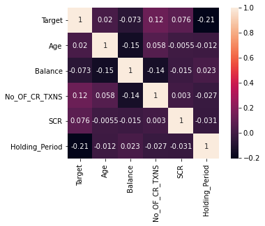

```python
sns.heatmap(data.corr(), annot=True, square=True) # No strong correlations seen overall
plt.show()
```

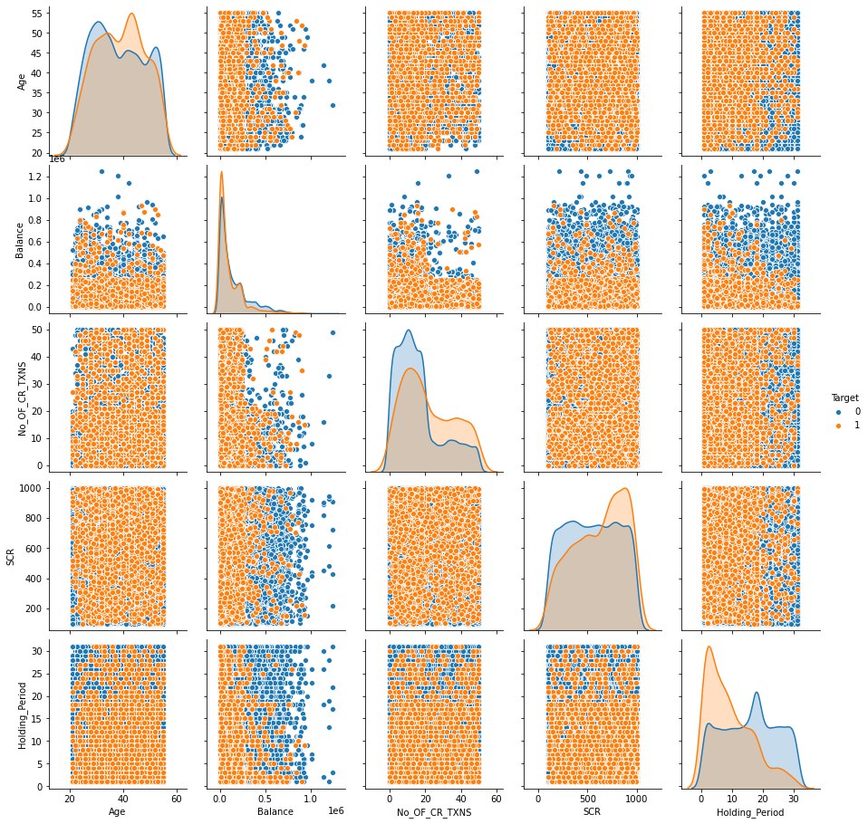

```python
sns.pairplot(data, hue='Target')
plt.show()
```

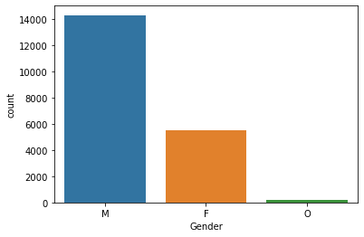

```python
sns.countplot(x = data.Gender)
plt.show()
```

###### Inferences:

- Since `GENDER` = `"OTHERS"/"O"` has very less population size i.e. less than 1% of entire data hence can be omitted as an attribute from `GENDER` category.

```python
data.Gender.unique()
```

```
array(['M', 'F', 'O'], dtype=object)
```

```python
data.Occupation.unique()
```

```
array(['SELF-EMP', 'SAL', 'SENP', 'PROF'], dtype=object)
```

```python
data.Gender.value_counts()
```

```
M    14279
F     5525
O      196
Name: Gender, dtype: int64
```

```python
data.drop(data.Gender[data.Gender== 'O'].index, axis = 0, inplace= True) # Removed 196 rows with `Gender` = 'O'
```

```python
data.shape
```

```
(19804, 8)
```

```python
data.Balance.describe()
```

```
count    1.980400e+04
mean     1.465609e+05
std      1.694485e+05
min      0.000000e+00
25%      2.399900e+04
50%      8.035100e+04
75%      2.183090e+05
max      1.246966e+06
Name: Balance, dtype: float64
```

```python
# sns.histplot(data.Age)
```

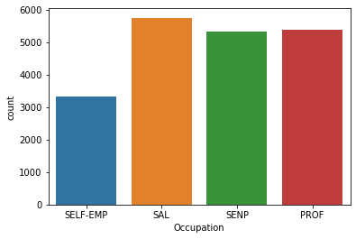

```python
sns.countplot(x = data.Occupation)
```

###### Inferences:

- The data consists mostly of `Salaried` category employees, whereas `Business Owners` and `Professionals` occupy the same strength in the data.

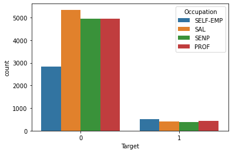

```python
sns.countplot(x=data.Target, hue=data.Occupation) ## Self employed are much more likely to take loans
```

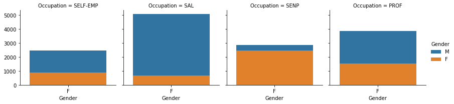

```python
g = sns.FacetGrid(data, col='Occupation', hue="Gender")
plt.grid(True)
g.map(sns.countplot, "Gender", alpha=1)
g.add_legend()
plt.grid((False))
```

###### Inferences:

```python
# sns.histplot(data.No_OF_CR_TXNS)
```

```python
data.No_OF_CR_TXNS.describe()
```

```
count    19804.000000
mean        16.563169
std         12.928214
min          0.000000
25%          7.000000
50%         13.000000
75%         21.000000
max         50.000000
Name: No_OF_CR_TXNS, dtype: float64
```

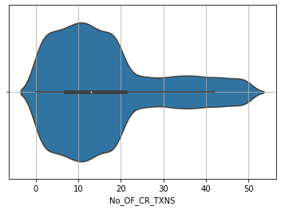

```python
sns.violinplot(x=data.No_OF_CR_TXNS)
plt.grid(True)
```

###### Inferences:

- The average `No. of Credit Transactions` tend to be in between 10 and 20. Whereas very few transactions tend to be in the number of 30-50.

```python
# len(data[data.No_OF_CR_TXNS==0].index)
```

```python
# data.drop(index=data[data.No_OF_CR_TXNS==0].index, axis=0)
```

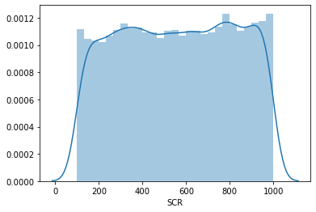

```python
# sns.displot(data.SCR, kind = 'kde')
sns.distplot(data.SCR)
plt.show()
```

###### Inferences:

- A uniform distribution can be observed for `SCR` and no skewness is found in the given data.

```python
data.SCR.describe()
```

```
count    19804.000000
mean       557.115987
std        260.562729
min        100.000000
25%        332.000000
50%        560.500000
75%        784.250000
max        999.000000
Name: SCR, dtype: float64
```

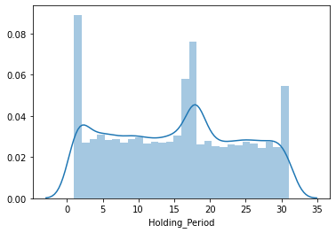

```python
sns.distplot(data.Holding_Period)
```

```python
data3 = data
```

### ------------------------------------------------------End of Exploratory Data Analysis-------------------------------------------------------

### Pretty Report Printing Function

```python
# A class for pretty printing
class color:
    PURPLE = '\033[95m'
    CYAN = '\033[96m'
    DARKCYAN = '\033[36m'
    BLUE = '\033[94m'
    GREEN = '\033[92m'
    YELLOW = '\033[93m'
    RED = '\033[91m'
    BOLD = '\033[1m'
    UNDERLINE = '\033[4m'
    END = '\033[0m'

# function for validation on test data
def classification_report(y_true, y_prediction, type_of_data='Enter Over/Under/Original sampled', type_of_classifier='ClassifierName'):
    """Print Classification report"""

    accuracy = accuracy_score(y_true, y_prediction)
    precision = precision_score(y_true, y_prediction)
    recall = recall_score(y_true, y_prediction)
    f1 = f1_score(y_true, y_prediction)

    print('Classification Report on Testing Data:\n'+ color.BOLD + type_of_data, 'data\n'+color.END+color.RED+color.BOLD+type_of_classifier,'Classifier'+color.END+color.END)
    print()
    print('---------------------------------------')
    print(color.BOLD + 'Recall: %s' %recall + color.END)
    print('Precision: %s' %precision)
    print('F1 score: %s' %f1)
    print('Accuracy: %s' %accuracy)
    print('---------------------------------------')
    print()


# A function for cross-validation report
def cross_val_report(classifier, train_data, train_label, cv=10, scoring=['recall','precision', 'f1','accuracy']):

    score = cross_validate(classifier, train_data, train_label, cv=cv, scoring= scoring)
    recall = np.mean(score['test_recall'])
    precision = np.mean(score['test_precision'])
    f1 = np.mean(score['test_f1'])
    accuracy= np.mean(score['test_accuracy'])
    print('Cross Validation Report')
    print(color.BOLD + 'Recall: %s' %recall + color.END)
    print('Precision: %s' %precision)
    print('F1: %s' %f1)
    print('Accuracy: %s' %accuracy)
    print()
    print("*Mean values presented")
    print('---------------------------------------')
```

### Creating the first set of training and test data on imbalanced data

```python
df = pd.get_dummies(data, columns=['Gender','Occupation'], drop_first = True)
df.head()
```

|  | Target | Age | Balance | No_OF_CR_TXNS | SCR | Holding_Period | Gender_M | Occupation_SAL | Occupation_SELF-EMP | Occupation_SENP |
| --- | --- | --- | --- | --- | --- | --- | --- | --- | --- | --- |
| 0 | 0 | 41 | 91519 | 38 | 926 | 15 | 1 | 0 | 1 | 0 |
| 1 | 0 | 52 | 117288 | 17 | 768 | 13 | 1 | 1 | 0 | 0 |
| 2 | 0 | 31 | 259827 | 8 | 816 | 5 | 0 | 0 | 0 | 1 |
| 3 | 0 | 45 | 26677 | 14 | 353 | 18 | 0 | 0 | 0 | 0 |
| 4 | 0 | 39 | 43440 | 1 | 751 | 31 | 0 | 0 | 0 | 1 |

#### Creating a model with Original Unbalanced data and measuring metrics

```python
X_original = df.iloc[:,1:]
y_original = df.iloc[:,0]
```

```python
X_original
```

|  | Age | Balance | No_OF_CR_TXNS | SCR | Holding_Period | Gender_M | Occupation_SAL | Occupation_SELF-EMP | Occupation_SENP |
| --- | --- | --- | --- | --- | --- | --- | --- | --- | --- |
| 0 | 41 | 91519 | 38 | 926 | 15 | 1 | 0 | 1 | 0 |
| 1 | 52 | 117288 | 17 | 768 | 13 | 1 | 1 | 0 | 0 |
| 2 | 31 | 259827 | 8 | 816 | 5 | 0 | 0 | 0 | 1 |
| 3 | 45 | 26677 | 14 | 353 | 18 | 0 | 0 | 0 | 0 |
| 4 | 39 | 43440 | 1 | 751 | 31 | 0 | 0 | 0 | 1 |
| ... | ... | ... | ... | ... | ... | ... | ... | ... | ... |
| 19995 | 23 | 67612 | 20 | 164 | 27 | 0 | 0 | 0 | 1 |
| 19996 | 34 | 472365 | 8 | 124 | 1 | 0 | 0 | 0 | 0 |
| 19997 | 42 | 100642 | 4 | 263 | 1 | 1 | 1 | 0 | 0 |
| 19998 | 36 | 29950 | 10 | 345 | 31 | 1 | 0 | 0 | 1 |
| 19999 | 33 | 48964 | 4 | 800 | 13 | 1 | 0 | 0 | 0 |

19804 rows × 9 columns

```python
X_train_orig, X_test_orig, y_train_orig, y_test_orig = train_test_split(X_original,y_original, shuffle = ['True'], stratify=y_original)
```

### ------------------------------------------------------Start of Model Exploration---------------------------------------------------------------

## DecisionTreeClassifier - Original Data

```
Classification Report on Testing Data:
Original data
Decision Tree Classifier

---------------------------------------
Recall: 0.11475409836065574
Precision: 0.5975609756097561
F1 score: 0.1925343811394892
Accuracy: 0.9169864673803272
---------------------------------------
```

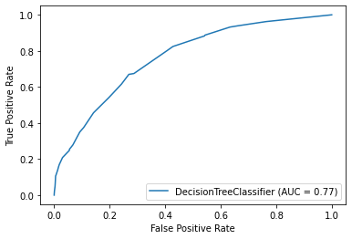

```python
clf = DecisionTreeClassifier(max_depth = 5)
clf.fit(X_train_orig, y_train_orig)
y_prediction_orig = clf.predict(X_test_orig)
classification_report(y_test_orig, y_prediction_orig, 'Original', 'Decision Tree')
plot_roc_curve(clf, X_test_orig, y_test_orig)
plt.show()
# cross_val_report(clf, y_test_orig,y_under_prediction.reshape(1,-1))
```

```python
from sklearn.metrics import confusion_matrix
```

```python
confusion_matrix(y_test_orig, y_prediction_orig)
```

```
array([[4491,   33],
       [ 378,   49]], dtype=int64)
```

### High confidence and correct, but low prediction count

#### Create undersampled data and fit a model

```python
X_under_train, y_under_train = NearMiss().fit_resample(X_train_orig, y_train_orig)
```

```python
data[data.Target==1].shape
```

```
(1709, 8)
```

```python
X_under_train.shape, y_under_train.shape
```

```
((2564, 9), (2564,))
```

## DecisionTreeClassifier - UnderSampled Data

```
Classification Report on Testing Data:
Undersampled data
Decision Tree Classifier

---------------------------------------
Recall: 0.7564402810304449
Precision: 0.09073033707865169
F1 score: 0.16202658640581893
Accuracy: 0.3251868309432438
---------------------------------------
```

```
<sklearn.metrics._plot.roc_curve.RocCurveDisplay at 0x133b2320f60>
```

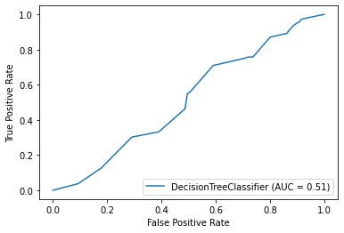

```python
clf_under_sampled = DecisionTreeClassifier(max_depth = 5)
clf_under_sampled.fit(X_under_train, y_under_train)
y_under_prediction = clf_under_sampled.predict(X_test_orig)
classification_report(y_test_orig,y_under_prediction, 'Undersampled', 'Decision Tree')
plot_roc_curve(clf_under_sampled, X_test_orig, y_test_orig)
```

```python
confusion_matrix(y_test_orig, y_under_prediction)
```

```
array([[1287, 3237],
       [ 104,  323]], dtype=int64)
```

Similar as above

```python
# cross_val_report(clf_under_sampled, y_test_orig,y_under_prediction)

## crossval here causes unbalanced split
```

```python
# fig = plt.figure(figsize=(100,100))
# _ = plot_tree(clf_under_sampled,
#                    feature_names=list(X_original.columns),
#                    class_names=['0','1'],
#                    filled=True, fontsize=10)
```

> Model on an oversampled dataset

```python
X_over_train, y_over_train = SMOTE().fit_resample(X_train_orig, y_train_orig)
```

## DecisionTreeClassifier - OverSampled Data

```
Classification Report on Testing Data:
Oversampled data
Decision Tree Classifier

---------------------------------------
Recall: 0.5386416861826698
Precision: 0.15862068965517243
F1 score: 0.24507192328183275
Accuracy: 0.7137951928903252
---------------------------------------
```

```
<sklearn.metrics._plot.roc_curve.RocCurveDisplay at 0x133b1d5e748>
```

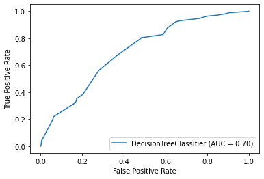

```python
clf_over_sampled = DecisionTreeClassifier(max_depth = 5)
clf_over_sampled.fit(X_over_train, y_over_train)
y_over_predict = clf_over_sampled.predict(X_test_orig)
classification_report(y_test_orig, y_over_predict, 'Oversampled', 'Decision Tree')
plot_roc_curve(clf_over_sampled, X_test_orig, y_test_orig)
```

```python
confusion_matrix(y_test_orig, y_over_predict)
```

```
array([[3304, 1220],
       [ 197,  230]], dtype=int64)
```

```python
s = 0.22805017103762829 ## higher predictions and better confidence
```

```python
# fig = plt.figure(figsize=(100,100))
# _ = plot_tree(clf_over_sampled,
#                    feature_names=list(X_original.columns),
#                    class_names=['0','1'],
#                    filled=True, fontsize=10)
```

```python
print("Original:     "+color.BOLD+ "X_original,y_original"+color.END+"::  X_train_orig, X_test_orig, y_train_orig, y_test_orig")
print()
print("Undersampled:"+color.BOLD+ " X_under, y_under"+color.END+"     ::  X_under_train, y_under_train")
print()
print("Oversampled:"+color.BOLD+ "  X_over, y_over"+color.END+"       ::  X_over_train, y_over_train")
```

```
Original:     X_original,y_original::  X_train_orig, X_test_orig, y_train_orig, y_test_orig

Undersampled: X_under, y_under     ::  X_under_train, y_under_train

Oversampled:  X_over, y_over       ::  X_over_train, y_over_train
```

The above datasets can be better sampled by adjusting hyper-parameters of NearMiss and SMOTE, or other methods of sampling could be used

## SVM Classifiers applied

*SVC fails to fit on original dataset, possibly because of unbalance*

```python
# clf_svc0 = SVC()
# clf_svc0.fit(X_under_train, y_under_train)
# y_predict = clf_svc0.predict(X_test_orig)
# classification_report(y_test_orig, y_predict, 'Undersampled', 'SVM')
# plot_roc_curve(clf_svc0, X_test_orig, y_test_orig)
# cross_val_report(clf_svc0, X_under_train, y_under_train)
```

```python
# confusion_matrix(y_test_orig, y_over_predict)
```

```python
# %%time
# # Will take LONG Time for Training
# clf_svc1 = SVC()
# clf_svc1.fit(X_over_train, y_over_train)
# y_predict = clf_svc1.predict(X_test_orig)
# classification_report(y_test_orig, y_predict, 'Oversampled', 'SVM')
# plot_roc_curve(clf_svc1, X_test_orig, y_test_orig)
# cross_val_report(clf_svc1, X_under_train, y_under_train)
```

## KNN Classifier - Original Data

```
Classification Report on Testing Data:
Original data
KNN Classifier

---------------------------------------
Recall: 0.06557377049180328
Precision: 0.3146067415730337
F1 score: 0.10852713178294573
Accuracy: 0.907089476873359
---------------------------------------

Cross Validation Report
Recall: 0.5942890019379845
Precision: 0.7121148835481202
F1: 0.6452145479690584
Accuracy: 0.6693093385214007

*Mean values presented
---------------------------------------
```

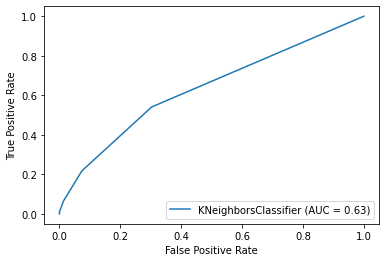

```python
clf_KNN0 = KNeighborsClassifier()
clf_KNN0.fit(X_train_orig, y_train_orig)
y_predict= clf_KNN0.predict(X_test_orig)
classification_report(y_test_orig, y_predict, 'Original', 'KNN')
plot_roc_curve(clf_KNN0, X_test_orig, y_test_orig)
cross_val_report(clf_KNN0, X_under_train, y_under_train)
```

```python
confusion_matrix(y_test_orig, y_predict)
```

```
array([[4463,   61],
       [ 399,   28]], dtype=int64)
```

```python
349/3050
```

```
0.11442622950819673
```

## KNN Classifier - Undersampled Data

```
Classification Report on Testing Data:
Undersampled data
KNN Classifier

---------------------------------------
Recall: 0.7236533957845434
Precision: 0.08013485477178424
F1 score: 0.14429138454354423
Accuracy: 0.25974550595839224
---------------------------------------

Cross Validation Report
Recall: 0.5942890019379845
Precision: 0.7121148835481202
F1: 0.6452145479690584
Accuracy: 0.6693093385214007

*Mean values presented
---------------------------------------
```

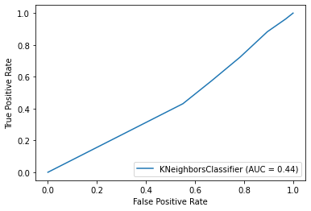

```python
clf_KNN1 = KNeighborsClassifier()
clf_KNN1.fit(X_under_train, y_under_train)
y_predict= clf_KNN1.predict(X_test_orig)
classification_report(y_test_orig, y_predict, 'Undersampled', 'KNN')
plot_roc_curve(clf_KNN1, X_test_orig, y_test_orig)
cross_val_report(clf_KNN1, X_under_train, y_under_train)
```

```python
confusion_matrix(y_test_orig, y_predict)
```

```
array([[ 977, 3547],
       [ 118,  309]], dtype=int64)
```

```python
311/3596
```

```
0.08648498331479422
```

## Random Forest Classifier - Original Data

```
Classification Report on Testing Data:
Original data
Random Forest Classifier

---------------------------------------
Recall: 0.12412177985948478
Precision: 0.6708860759493671
F1 score: 0.20948616600790512
Accuracy: 0.9192082407594425
---------------------------------------

Cross Validation Report
Recall: 0.7846596414728683
Precision: 0.8039120988398236
F1: 0.7930381164518722
Accuracy: 0.7952197835603113

*Mean values presented
---------------------------------------
```

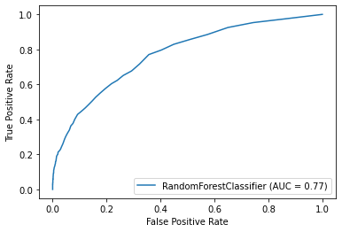

```python
clf_rf0 = RandomForestClassifier()
clf_rf0.fit(X_train_orig, y_train_orig)
y_predict= clf_rf0.predict(X_test_orig)
classification_report(y_test_orig, y_predict, 'Original', 'Random Forest')
plot_roc_curve(clf_rf0, X_test_orig, y_test_orig)
cross_val_report(clf_rf0, X_under_train, y_under_train)
```

```python
confusion_matrix(y_test_orig, y_predict)
```

```
array([[4498,   26],
       [ 374,   53]], dtype=int64)
```

```
<sklearn.inspection._plot.partial_dependence.PartialDependenceDisplay at 0x133b2180ba8>
```

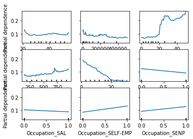

```python
plot_partial_dependence(clf_rf0, X_test_orig, X_test_orig.columns)
```

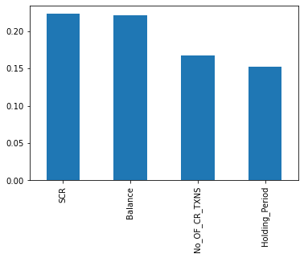

```python
(pd.Series(clf_rf0.feature_importances_, index=X_test_orig.columns)
   .nlargest(4)
   .plot(kind='bar'))
```

##### Inferences:

- The prominent features are: `SCR`,`BALANCE`,`No_OF_CR_TXNS`,`Holding_Period`

## RFE Implementation

```python
from sklearn.feature_selection import RFE
```

```python
rfe = RFE(RandomForestClassifier(), n_features_to_select=4)
rfe = rfe.fit(X_over_train, y_over_train)
# summarize the selection of the attributes
print(rfe.support_)
print(rfe.ranking_)
```

```
[False  True  True  True  True False False False False]
[2 1 1 1 1 5 3 6 4]
```

```python
X_over_train.columns
```

```
Index(['Age', 'Balance', 'No_OF_CR_TXNS', 'SCR', 'Holding_Period', 'Gender_M',
       'Occupation_SAL', 'Occupation_SELF-EMP', 'Occupation_SENP'],
      dtype='object')
```

##### Inferences:

- RFE algorithm decided prominent features: `SCR`,`BALANCE`,`No_OF_CR_TXNS`,`Holding_Period`

```python
categorical_features_indices = np.where(X_train_orig.dtypes != np.float)[0]
```

```python
categorical_features_indices
```

```
array([0, 1, 2, 3, 4, 5, 6, 7, 8], dtype=int64)
```

## RandomForest Classifier - Undersampled Data

```python
X_train_orig.columns
```

```
Index(['Age', 'Balance', 'No_OF_CR_TXNS', 'SCR', 'Holding_Period', 'Gender_M',
       'Occupation_SAL', 'Occupation_SELF-EMP', 'Occupation_SENP'],
      dtype='object')
```

```
Classification Report on Testing Data:
Undersampled data
Random Forest Classifier

---------------------------------------
Recall: 0.8032786885245902
Precision: 0.10384498940357251
F1 score: 0.1839142091152815
Accuracy: 0.3851747121793577
---------------------------------------

Cross Validation Report
Recall: 0.7800024224806201
Precision: 0.7984371446798858
F1: 0.7881579076009938
Accuracy: 0.7897647130350195

*Mean values presented
---------------------------------------
```

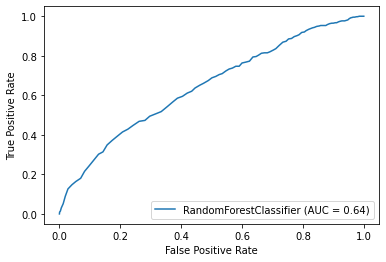

```python
clf_rf1 = RandomForestClassifier()
clf_rf1.fit(X_under_train, y_under_train)
y_predict= clf_rf1.predict(X_test_orig)
classification_report(y_test_orig, y_predict, 'Undersampled', 'Random Forest')
plot_roc_curve(clf_rf1, X_test_orig, y_test_orig)
cross_val_report(clf_rf1, X_under_train, y_under_train)
```

```python
confusion_matrix(y_test_orig, y_predict)
```

```
array([[1564, 2960],
       [  84,  343]], dtype=int64)
```

```python
clf_rf2 = RandomForestClassifier()
```

```
Classification Report on Testing Data:
Oversampled data
Random Forest Classifier

---------------------------------------
Recall: 0.8032786885245902
Precision: 0.10247983268598745
F1 score: 0.1817700052994171
Accuracy: 0.3762876186628964
---------------------------------------

Cross Validation Report
Recall: 0.7815830910852714
Precision: 0.7967041598178917
F1: 0.7880603032656348
Accuracy: 0.7893847276264592

*Mean values presented
---------------------------------------
```

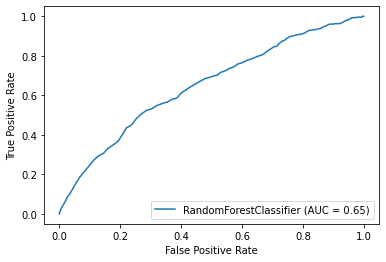

```python
clf_rf2.fit(X_under_train, y_under_train)
y_predict= clf_rf2.predict(X_test_orig)
classification_report(y_test_orig, y_predict, 'Oversampled', 'Random Forest')
plot_roc_curve(clf_rf2, X_test_orig, y_test_orig)
cross_val_report(clf_rf2, X_under_train, y_under_train)
```

```python
confusion_matrix(y_test_orig, y_predict)
```

```
array([[1520, 3004],
       [  84,  343]], dtype=int64)
```

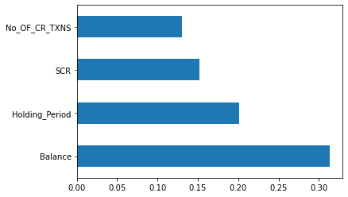

```python
(pd.Series(clf_rf2.feature_importances_, index=X_test_orig.columns)
   .nlargest(4)
   .plot(kind='barh'))
```

## Logistic Regression - Original Data

```python
from sklearn.linear_model import LogisticRegression
```

```
Classification Report on Testing Data:
Original data
Logistic Regression Classifier

---------------------------------------
Recall: 0.0
Precision: 0.0
F1 score: 0.0
Accuracy: 0.9137547970107049
---------------------------------------

Cross Validation Report
Recall: 0.6810319767441861
Precision: 0.6656499789179551
F1: 0.6724621491476083
Accuracy: 0.6685265685797666

*Mean values presented
---------------------------------------
```

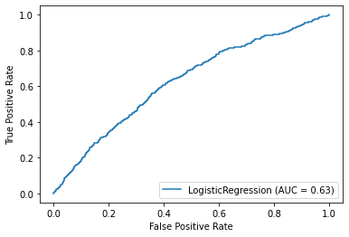

```python
lr0 = LogisticRegression(max_iter=1000)
lr0.fit(X_train_orig, y_train_orig)
y_predict= lr0.predict(X_test_orig)
classification_report(y_test_orig, y_predict, 'Original', 'Logistic Regression')
plot_roc_curve(lr0, X_test_orig, y_test_orig)
cross_val_report(lr0, X_under_train, y_under_train)
```

```python
confusion_matrix(y_test_orig, y_predict)
```

```
array([[4524,    0],
       [ 427,    0]], dtype=int64)
```

## Logistic Regression - Undersampled Data

```
Classification Report on Testing Data:
Undersampled data
Logistic Regression Classifier

---------------------------------------
Recall: 0.7166276346604216
Precision: 0.1476833976833977
F1 score: 0.2448979591836735
Accuracy: 0.6188648757826701
---------------------------------------
```

```
Cross Validation Report
Recall: 0.6810319767441861
Precision: 0.6656499789179551
F1: 0.6724621491476083
Accuracy: 0.6685265685797666

*Mean values presented
---------------------------------------
```

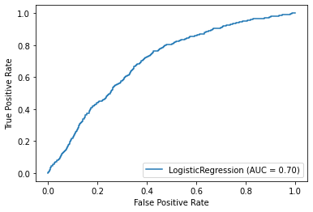

```python
lr1 = LogisticRegression(max_iter=100)
lr1.fit(X_under_train, y_under_train)
y_predict= lr1.predict(X_test_orig)
classification_report(y_test_orig, y_predict, 'Undersampled', 'Logistic Regression')
plot_roc_curve(lr1, X_test_orig, y_test_orig)
cross_val_report(lr1, X_under_train, y_under_train)
```

```python
confusion_matrix(y_test_orig, y_predict)
```

```
array([[2758, 1766],
       [ 121,  306]], dtype=int64)
```

## Logistic Regression - Oversampled Data

```
Classification Report on Testing Data:
Oversampled data
Logistic Regression Classifier

---------------------------------------
Recall: 0.6721311475409836
Precision: 0.16666666666666666
F1 score: 0.2671009771986971
Accuracy: 0.681882447990305
---------------------------------------
```

```
Cross Validation Report
Recall: 0.6810319767441861
Precision: 0.6656499789179551
F1: 0.6724621491476083
Accuracy: 0.6685265685797666

*Mean values presented
---------------------------------------
```

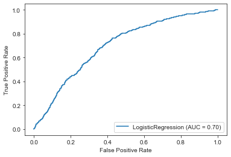

```python
lr2 = LogisticRegression(max_iter=100)
lr2.fit(X_over_train, y_over_train)
y_predict= lr2.predict(X_test_orig)
classification_report(y_test_orig, y_predict, 'Oversampled', 'Logistic Regression')
plot_roc_curve(lr1, X_test_orig, y_test_orig)
cross_val_report(lr1, X_under_train, y_under_train)
```

```python
confusion_matrix(y_test_orig, y_predict)
```

```
array([[3089, 1435],
       [ 140,  287]], dtype=int64)
```

## KNN Classifier - Oversampled Data

```
Classification Report on Testing Data:
Oversampled data
KNN Classifier

---------------------------------------
Recall: 0.5245901639344263
Precision: 0.15523215523215522
F1 score: 0.23957219251336895
Accuracy: 0.7127852958998182
---------------------------------------

Cross Validation Report
Recall: 0.5942890019379845
Precision: 0.7121148835481202
F1: 0.6452145479690584
Accuracy: 0.6693093385214007

*Mean values presented
---------------------------------------
```

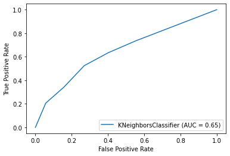

```python
clf_KNN2 = KNeighborsClassifier()
clf_KNN2.fit(X_over_train, y_over_train)
y_predict= clf_KNN2.predict(X_test_orig)
classification_report(y_test_orig, y_predict, 'Oversampled', 'KNN')
plot_roc_curve(clf_KNN2, X_test_orig, y_test_orig)
cross_val_report(clf_KNN2, X_under_train, y_under_train)
```

```python
confusion_matrix(y_test_orig, y_predict)
```

```
array([[3305, 1219],
       [ 203,  224]], dtype=int64)
```

*Segment the customer with prob >90, 80>prob>90, 70>prob>80, 60>prob>70 and so on*

```python
predict_prob = clf_KNN2.predict_proba(X_test_orig)
predict_prob.shape
# print more significant digits here
```

```
(4951, 2)
```

```python
# predict_prob
```

```python
predictions = pd.DataFrame(predict_prob, columns=[0, 'PredictionProb'])
```

```python
# predictions.head()
```

```python
predictions_prob = predictions.drop(0, axis=1)
```

```python
y = pd.DataFrame(y_test_orig, columns = ['Target'])
y = y.reset_index(drop=True)
```

```python
error = y.Target- predictions_prob.PredictionProb
```

```python
# This series indicate the error, closer to zero values mean better prediction
# positive mean that my model should have predicted loan taker, but did not
# negative means that model should have predicted NOT a loan taker, but did predict as such
```

## Target - Probablity - KNN

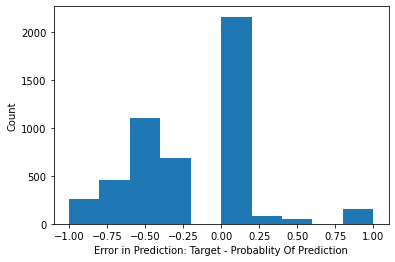

```python
plt.hist(error)
plt.xlabel('Error in Prediction: Target - Probablity Of Prediction')
plt.ylabel("Count")
plt.show()
```

### ------------------------------------------------------End of Model Exploration---------------------------------------------------------------

## PRE-BUCKETING VISUALIZATIONS FOR INFERENCES

### SCR Vs Occupation Vs Target

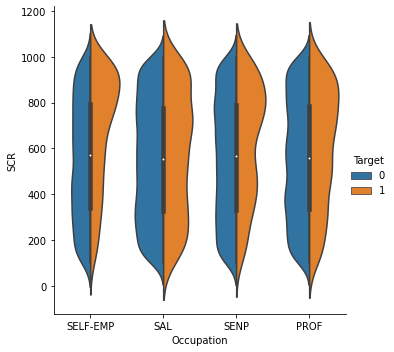

```python
sns.catplot(x="Occupation", y="SCR", hue = "Target",data=data, kind = "violin", split = True)
plt.show()
```

##### Inferences:

- `SELF-EMP` class tends to have more `SCR` values who are likely to opt for loans.
- `SAL` class shows uniformity across `SCR` for people opting/not opting for loans.
- `SENP` business class tend to show similar fashion like `SELF-EMP` class when it comes to opting for loans.
- `PROF` class tends to lie somewhere between `SENP` and `SAL` class.

### SCR Vs Occupation Vs Target

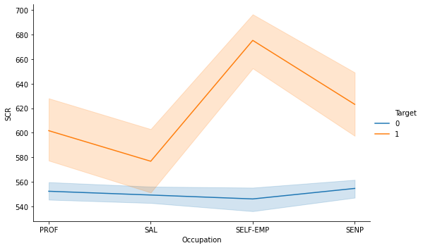

```python
sns.relplot(x="Occupation", y="SCR", hue = "Target",data=data, aspect=1.5, kind = "line")
plt.show()
```

### SCR Vs Occupation Vs Target

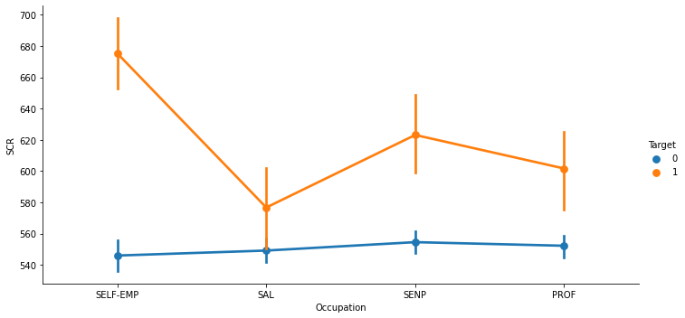

```python
sns.catplot(x="Occupation", y="SCR", hue = "Target",data=data, aspect=2.0, kind = "point")
plt.show()
```

##### Inferences:

- `SELF-EMP`class, there can be seen a high `SCR` value ranging between 660 to 700 points who have shown interest in opting for loans whereas least interest in the same class was shown at 540 to 550 points of `SCR`
- `SENP` class. are the second in line to opt for Loans, as they tend to show comaratively hgiher `SCR` values in the line graph above.

```python
data1 = data.copy()
```

## Bucketing for AGE values

#### pd.qcut() function

```python
data1['Ageb'] = pd.qcut(data['Age'], q=4)
```

```python
data1.head()
```

|  | Target | Age | Gender | Balance | Occupation | No_OF_CR_TXNS | SCR | Holding_Period | Ageb |
| --- | --- | --- | --- | --- | --- | --- | --- | --- | --- |
| 0 | 0 | 41 | M | 91519 | SELF-EMP | 38 | 926 | 15 | (38.0, 46.0] |
| 1 | 0 | 52 | M | 117288 | SAL | 17 | 768 | 13 | (46.0, 55.0] |
| 2 | 0 | 31 | F | 259827 | SENP | 8 | 816 | 5 | (30.0, 38.0] |
| 3 | 0 | 45 | F | 26677 | PROF | 14 | 353 | 18 | (38.0, 46.0] |
| 4 | 0 | 39 | F | 43440 | SENP | 1 | 751 | 31 | (38.0, 46.0] |

#### AGE Intervals

```python
data1.Ageb.value_counts()
```

```
(30.0, 38.0]      5188
(20.999, 30.0]    5136
(46.0, 55.0]      4936
(38.0, 46.0]      4544
Name: Ageb, dtype: int64
```

```python
data1.dtypes
```

```
Target               int64
Age                  int64
Gender              object
Balance              int32
Occupation          object
No_OF_CR_TXNS        int64
SCR                  int64
Holding_Period       int64
Ageb              category
dtype: object
```

```python
data1.Ageb
```

```
0          (38.0, 46.0]
1          (46.0, 55.0]
2          (30.0, 38.0]
3          (38.0, 46.0]
4          (38.0, 46.0]
              ...
19995    (20.999, 30.0]
19996      (30.0, 38.0]
19997      (38.0, 46.0]
19998      (30.0, 38.0]
19999      (30.0, 38.0]
Name: Ageb, Length: 19804, dtype: category
Categories (4, interval[float64]): [(20.999, 30.0] < (30.0, 38.0] < (38.0, 46.0] < (46.0, 55.0]]
```

```python
data1.head(5)
```

|  | Target | Age | Gender | Balance | Occupation | No_OF_CR_TXNS | SCR | Holding_Period | Ageb |
| --- | --- | --- | --- | --- | --- | --- | --- | --- | --- |
| 0 | 0 | 41 | M | 91519 | SELF-EMP | 38 | 926 | 15 | (38.0, 46.0] |
| 1 | 0 | 52 | M | 117288 | SAL | 17 | 768 | 13 | (46.0, 55.0] |
| 2 | 0 | 31 | F | 259827 | SENP | 8 | 816 | 5 | (30.0, 38.0] |
| 3 | 0 | 45 | F | 26677 | PROF | 14 | 353 | 18 | (38.0, 46.0] |
| 4 | 0 | 39 | F | 43440 | SENP | 1 | 751 | 31 | (38.0, 46.0] |

```python
# sns.pairplot(data1, hue='Target')
```

```python
data1 = pd.get_dummies(data1)
```

```python
data1.head(2)
```

|  | Target | Age | Balance | No_OF_CR_TXNS | SCR | Holding_Period | Gender_F | Gender_M | Occupation_PROF | Occupation_SAL | Occupation_SELF-EMP | Occupation_SENP | Ageb_(20.999, 30.0] | Ageb_(30.0, 38.0] | Ageb_(38.0, 46.0] | Ageb_(46.0, 55.0] |
| --- | --- | --- | --- | --- | --- | --- | --- | --- | --- | --- | --- | --- | --- | --- | --- | --- |
| 0 | 0 | 41 | 91519 | 38 | 926 | 15 | 0 | 1 | 0 | 0 | 1 | 0 | 0 | 0 | 1 | 0 |
| 1 | 0 | 52 | 117288 | 17 | 768 | 13 | 0 | 1 | 0 | 1 | 0 | 0 | 0 | 0 | 0 | 1 |

```python
data2 = data1.copy()
```

```python
data1.columns
```

```
Index(['Target', 'Age', 'Balance', 'No_OF_CR_TXNS', 'SCR', 'Holding_Period',
       'Gender_F', 'Gender_M', 'Occupation_PROF', 'Occupation_SAL',
       'Occupation_SELF-EMP', 'Occupation_SENP', 'Ageb_(20.999, 30.0]',
       'Ageb_(30.0, 38.0]', 'Ageb_(38.0, 46.0]', 'Ageb_(46.0, 55.0]'],
      dtype='object')
```

### Age Bucket Ranking Function

```python
cols = ['Ageb_(30.0, 38.0]', 'Ageb_(20.999, 30.0]','Ageb_(46.0, 55.0]','Ageb_(38.0, 46.0]']

def func1(x):
    if x ==1:
        return 1
def func2(x):
    if x ==1:
        return 2

def func3(x):
    if x ==1:
        return 3

def func4(x):
    if x ==1:
        return 4


data1['age_d'] = data1['Ageb_(30.0, 38.0]'].apply(func1)
data1['age_d'] = data1['Ageb_(20.999, 30.0]'].apply(func2)
data1['age_d'] = data1['Ageb_(46.0, 55.0]'].apply(func3)
data1['age_d'] = data1['Ageb_(38.0, 46.0]'].apply(func4)
```

```python
for ind, row in data1.iterrows():
    if row['Ageb_(20.999, 30.0]'] ==1:
        data1.loc[ind, 'age_d'] = 1
    elif row['Ageb_(30.0, 38.0]'] ==1:
        data1.loc[ind, 'age_d'] = 2
    elif row['Ageb_(38.0, 46.0]'] ==1:
        data1.loc[ind, 'age_d'] = 3
    elif row['Ageb_(46.0, 55.0]'] ==1:
        data1.loc[ind, 'age_d'] = 4
```

```python
data1.age_d.value_counts()
```

```
2.0    5188
1.0    5136
4.0    4936
3.0    4544
Name: age_d, dtype: int64
```

#### Converting Age buckets to integer type

```python
data1.age_d = data1.age_d.astype('int32')
```

```python
data1.head()
```

|  | Target | Age | Balance | No_OF_CR_TXNS | SCR | Holding_Period | Gender_F | Gender_M | Occupation_PROF | Occupation_SAL | Occupation_SELF-EMP | Occupation_SENP | Ageb_(20.999, 30.0] | Ageb_(30.0, 38.0] | Ageb_(38.0, 46.0] | Ageb_(46.0, 55.0] | age_d |
| --- | --- | --- | --- | --- | --- | --- | --- | --- | --- | --- | --- | --- | --- | --- | --- | --- | --- |
| 0 | 0 | 41 | 91519 | 38 | 926 | 15 | 0 | 1 | 0 | 0 | 1 | 0 | 0 | 0 | 1 | 0 | 3 |
| 1 | 0 | 52 | 117288 | 17 | 768 | 13 | 0 | 1 | 0 | 1 | 0 | 0 | 0 | 0 | 0 | 1 | 4 |
| 2 | 0 | 31 | 259827 | 8 | 816 | 5 | 1 | 0 | 0 | 0 | 0 | 1 | 0 | 1 | 0 | 0 | 2 |
| 3 | 0 | 45 | 26677 | 14 | 353 | 18 | 1 | 0 | 1 | 0 | 0 | 0 | 0 | 0 | 1 | 0 | 3 |
| 4 | 0 | 39 | 43440 | 1 | 751 | 31 | 1 | 0 | 0 | 0 | 0 | 1 | 0 | 0 | 1 | 0 | 3 |